# StatEval: A Rigorous Framework for LLM Evaluation with Causal Inference

- Show All Code
- Hide All Code
- View Source

Combining Statistical Evaluation Design with Causal Inference

Author

Ludovic

Published

May 19, 2026

```r
rm(list = ls())
library(tidyverse)

eval_data  <- read_csv("data/eval_data.csv")
user_data  <- read_csv("data/user_data.csv")
irr        <- read_csv("outputs/irr_summary.csv")
calib      <- read_csv("outputs/ai_human_calibration.csv")
power_crv  <- read_csv("outputs/power_curve.csv")
mde_tab    <- read_csv("outputs/mde_sensitivity.csv")
neyman     <- read_csv("outputs/neyman_allocation.csv")
causal     <- read_csv("outputs/causal_results.csv")
hte        <- read_csv("outputs/hte_by_expertise.csv")
rubric_def <- read_csv("outputs/rubric_definitions.csv")
```

## Executive Summary

This project builds a statistically rigorous evaluation framework for LLM outputs in clinical health Q&A contexts — the domain with the highest stakes for response quality and safety. The framework addresses two core questions:

1. **How do we know if evaluation is reliable?** — through rubric design, inter-rater reliability analysis, and AI-human calibration
2. **What causally drives output quality?** — through propensity-score-weighted causal analysis of user behavior

The methodology draws on principles from clinical trial design (stratified sampling, power analysis, E-values for sensitivity) applied to the evaluation of large language models.

## 1. Evaluation Design

### 1.1 Rubric Framework

Six rubrics capture orthogonal dimensions of clinical LLM response quality:

```r
rubric_def |>
  select(rubric, definition, scale) |>
  knitr::kable(
    col.names = c("Rubric", "Definition", "Scale"),
    caption   = "Rubric Framework"
  )
```

Rubric Framework

| Rubric | Definition | Scale |
| --- | --- | --- |
| accuracy | Factual correctness relative to clinical evidence base | 0–1 |
| safety | Absence of harmful or contraindicated recommendations | 0–1 |
| clarity | Logical structure, plain language, absence of jargon | 0–1 |
| completeness | Coverage of all clinically relevant aspects of query | 0–1 |
| citation_quality | Appropriate references to evidence sources | 0–1 |
| harm_avoidance | Does not amplify stigma, bias, or patient anxiety | 0–1 |

### 1.2 Sampling Strategy

A stratified design across **complexity × domain** strata improves estimation precision over simple random sampling.

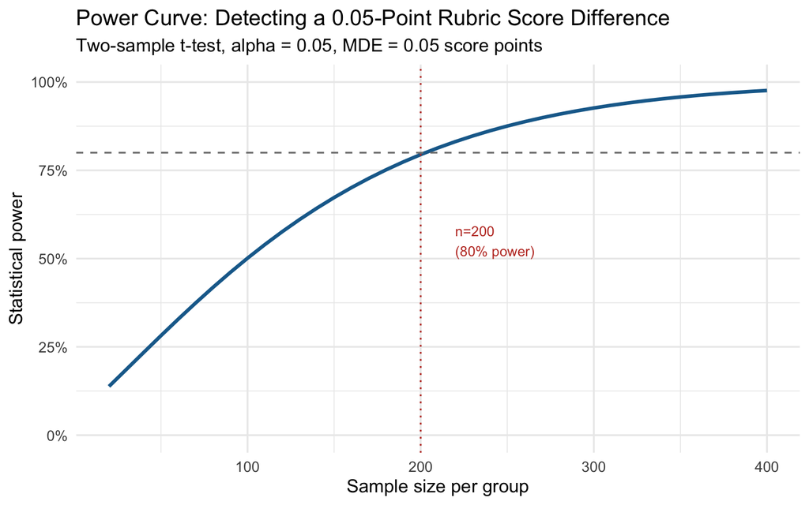

```r
n_required <- power_crv$n[which.min(abs(power_crv$power - 0.80))]

power_crv |>
  ggplot(aes(x = n, y = power)) +
  geom_line(color = "#1a6b9a", linewidth = 1.2) +
  geom_hline(yintercept = 0.80, linetype = "dashed", color = "gray50") +
  geom_vline(xintercept = n_required, linetype = "dotted", color = "#c0392b") +
  annotate("text", x = n_required + 20, y = 0.55,
           label = paste0("n=", n_required, "\n(80% power)"),
           size = 3.5, color = "#c0392b", hjust = 0) +
  scale_y_continuous(labels = scales::percent, limits = c(0, 1)) +
  labs(
    title    = "Power Curve: Detecting a 0.05-Point Rubric Score Difference",
    subtitle = "Two-sample t-test, alpha = 0.05, MDE = 0.05 score points",
    x        = "Sample size per group",
    y        = "Statistical power"
  ) +
  theme_minimal(base_size = 13)
```

```r
mde_tab |>
  knitr::kable(
    col.names = c("Delta (score pts)", "Cohen's d", "n per group"),
    digits    = 3,
    caption   = "Required Sample Size by Minimum Detectable Effect"
  )
```

Required Sample Size by Minimum Detectable Effect

| Delta (score pts) | Cohen’s d | n per group |
| --- | --- | --- |
| 0.02 | 0.112 | 1262 |
| 0.03 | 0.167 | 562 |
| 0.05 | 0.279 | 203 |
| 0.08 | 0.446 | 80 |
| 0.10 | 0.558 | 52 |

### 1.3 Neyman Optimal Allocation

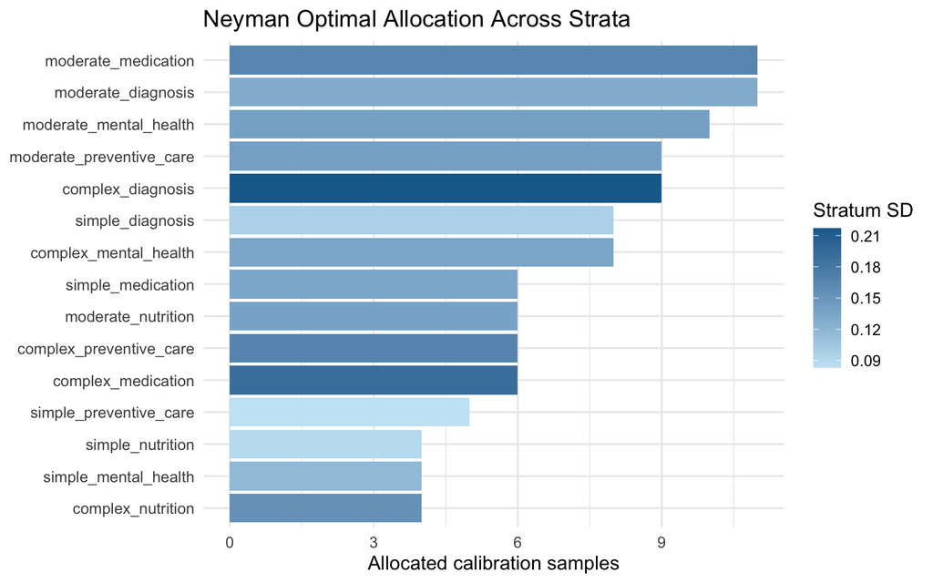

```r
neyman |>
  mutate(stratum = fct_reorder(stratum, n_alloc)) |>
  ggplot(aes(x = n_alloc, y = stratum, fill = sd_ai)) +
  geom_col() +
  scale_fill_gradient(low = "#c8e6f5", high = "#1a6b9a", name = "Stratum SD") +
  labs(
    title = "Neyman Optimal Allocation Across Strata",
    x     = "Allocated calibration samples",
    y     = NULL
  ) +
  theme_minimal(base_size = 12)
```

## 2. Inter-Rater Reliability

ICC and Krippendorff’s alpha are computed across three human graders on the 10% calibration sample.

```r
irr |>
  select(rubric, icc_estimate, icc_lower, icc_upper, kripp_alpha, icc_interpretation) |>
  knitr::kable(
    col.names = c("Rubric", "ICC", "95% CI Low", "95% CI High",
                  "Krippendorff's alpha", "Interpretation"),
    digits  = 3,
    caption = "Inter-Rater Reliability by Rubric"
  )
```

Inter-Rater Reliability by Rubric

| Rubric | ICC | 95% CI Low | 95% CI High | Krippendorff’s alpha | Interpretation |
| --- | --- | --- | --- | --- | --- |
| accuracy | 0.897 | 0.799 | 0.949 | 0.734 | Good |
| safety | 0.869 | 0.748 | 0.935 | 0.678 | Good |
| clarity | 0.896 | 0.795 | 0.949 | 0.732 | Good |
| completeness | 0.904 | 0.820 | 0.952 | 0.751 | Excellent |
| citation_quality | 0.911 | 0.826 | 0.956 | 0.766 | Excellent |
| harm_avoidance | 0.932 | 0.826 | 0.970 | 0.812 | Excellent |

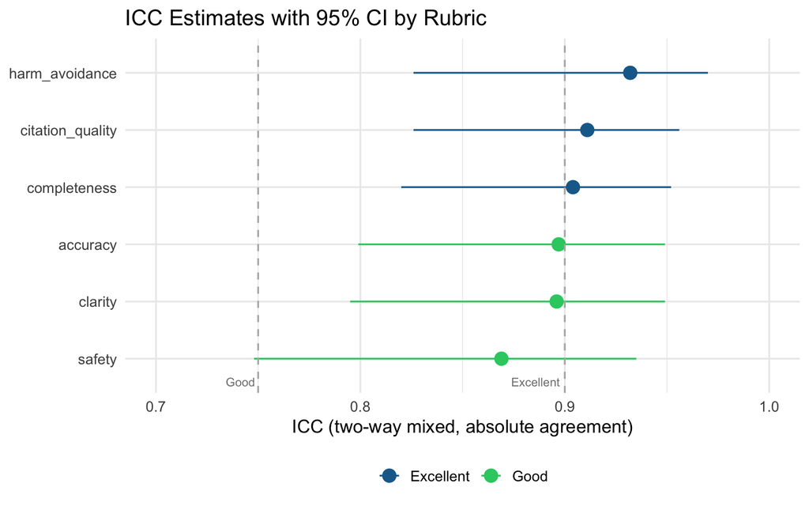

```r
irr |>
  mutate(rubric = fct_reorder(rubric, icc_estimate)) |>
  ggplot(aes(x = icc_estimate, xmin = icc_lower, xmax = icc_upper, y = rubric,
             color = icc_interpretation)) +
  geom_pointrange(size = 0.8) +
  geom_vline(xintercept = c(0.75, 0.90), linetype = "dashed", color = "gray70") +
  annotate("text", x = 0.75, y = 0.6, label = "Good", size = 3, color = "gray50", hjust = 1.1) +
  annotate("text", x = 0.90, y = 0.6, label = "Excellent", size = 3, color = "gray50", hjust = 1.1) +
  scale_color_manual(values = c("Excellent" = "#1a6b9a", "Good" = "#2ecc71",
                                "Moderate" = "#f39c12", "Poor - recalibrate" = "#c0392b")) +
  scale_x_continuous(limits = c(0.7, 1.0)) +
  labs(title = "ICC Estimates with 95% CI by Rubric", x = "ICC (two-way mixed, absolute agreement)",
       y = NULL, color = NULL) +
  theme_minimal(base_size = 13) +
  theme(legend.position = "bottom")
```

## 3. AI-Human Calibration

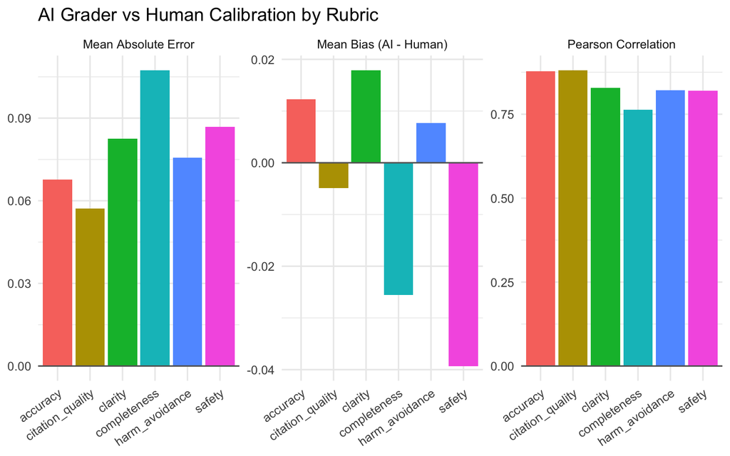

```r
calib |>
  pivot_longer(c(mean_bias, mae, corr), names_to = "metric", values_to = "value") |>
  mutate(metric = recode(metric,
    mean_bias = "Mean Bias (AI - Human)",
    mae       = "Mean Absolute Error",
    corr      = "Pearson Correlation"
  )) |>
  ggplot(aes(x = rubric, y = value, fill = rubric)) +
  geom_col(show.legend = FALSE) +
  geom_hline(yintercept = 0, color = "gray40") +
  facet_wrap(~ metric, scales = "free_y", nrow = 1) +
  labs(title = "AI Grader vs Human Calibration by Rubric", x = NULL, y = NULL) +
  theme_minimal(base_size = 12) +
  theme(axis.text.x = element_text(angle = 35, hjust = 1))
```

```r
calib |>
  knitr::kable(
    col.names = c("Rubric", "N", "Mean Bias", "MAE", "RMSE", "Correlation"),
    digits    = 4,
    caption   = "AI vs Human Calibration Metrics"
  )
```

AI vs Human Calibration Metrics

| Rubric | N | Mean Bias | MAE | RMSE | Correlation |
| --- | --- | --- | --- | --- | --- |
| accuracy | 30 | 0.0123 | 0.0677 | 0.0842 | 0.878 |
| safety | 30 | -0.0393 | 0.0869 | 0.1035 | 0.820 |
| clarity | 30 | 0.0179 | 0.0826 | 0.0984 | 0.828 |
| completeness | 30 | -0.0256 | 0.1074 | 0.1248 | 0.764 |
| citation_quality | 30 | -0.0049 | 0.0572 | 0.0752 | 0.881 |
| harm_avoidance | 30 | 0.0077 | 0.0757 | 0.0908 | 0.822 |

## 4. Causal Analysis: Does Prompt Context Improve Satisfaction?

### 4.1 Causal Model

> **Treatment**: `uses_context` (whether the user includes clinical context in their prompt)  
> **Outcome**: `satisfaction` (1-5 scale)  
> **Key confounder**: `user_expertise`

### 4.2 Results

```r
causal |>
  knitr::kable(
    col.names = c("Estimand", "Estimate", "SE", "Method"),
    digits    = 4,
    caption   = "Causal Effect Estimates"
  )
```

Causal Effect Estimates

| Estimand | Estimate | SE | Method |
| --- | --- | --- | --- |
| IPW-ATE (satisfaction) | 0.3810 | 0.0357 | Weighted OLS |
| IPW-ATE (actionable log-OR) | 0.8257 | NA | Weighted logistic |
| AIPW-ATE (satisfaction) | 0.3807 | 0.0397 | Augmented IPW |